# Vigilancia en Salud Pública: Análisis de datos y difusión de la información

Andree Valle Campos avallecam@gmail.com

2021-05-31

# Advertencias

> Este documento está plegado de [**hipervínculos**](https://es.wikipedia.org/wiki/Hiperenlace), ¡aprovéchalos!

> En los recuadros con `código en R`, ¡usa el botón de la esquina superior derecha para **copiar y pegar** el contenido!

> Los participantes deben conocer y comprometerse a cumplir el siguiete [Código de Conducta](https://www.metadocencia.org/cdc/). Tómate 5 minutos para leerlo

# Objetivos

- Analizar bases de datos provenientes de un sistema de vigilancia usando `R`
- Generar gráficos con el paquete `ggplot2` para describir en tiempo y espacio
- Generar tablas con el paquete `compareGroups` para describir caracteristicas de persona
- Estimar medidas de asociación con la función `stats::glm` para identificar factores de riesgo
- Limpiar las salidas de la función `stats::glm` con el paquete `epitidy`
- Construir una curva epidémica con el paquete `incidence` para calcular indicadores de tasa de crecimiento y tiempo de duplicación
- Limpiar las salidas del paquete `incidence` con el paquete `incidenceflow`
- Construir un canal endémico con `epichannel` para identificar zonas de éxito, seguridad, alerta y epidemia

# 00 - ¿cómo empezar con R?

## paso a paso

1. Desmitificar el uso de R creando *gráficos* y resolviendo *ejercicios interactivos* [con Rstudio primers](https://rstudio.cloud/learn/primers/1)
2. Instalar R, Rstudio y un paquete con los siguientes [pasos](https://learnr-examples.shinyapps.io/ex-setup-r/)
- Si llegas a presentar algún problema en tu computador, puedes acceder a través de tu buscador [aquí](https://rstudio.cloud/project/2585406)
3. Instalar paquetes a usar aquí con la función `install.packages()`. (Pista: solo copiar y pegar!)

```r
if(!require("remotes")) install.packages("remotes")
if(!require("tidyverse")) install.packages("tidyverse")
if(!require("lubridate")) install.packages("lubridate")
if(!require("compareGroups")) install.packages("compareGroups")
if(!require("rio")) install.packages("rio")
if(!require("naniar")) install.packages("naniar")
if(!require("incidence")) install.packages("incidence")
if(!require("epiR")) install.packages("epiR")
if(!require("epiDisplay")) install.packages("epiDisplay")
if(!require("epitidy")) remotes::install_github("avallecam/epitidy")
if(!require("incidenceflow")) remotes::install_github("avallecam/incidenceflow")
if(!require("epichannel")) remotes::install_github("avallecam/epichannel")
```

4. Crear una carpeta de trabajo y proyecto en Rstudio. Más detalles del ¿qué, por qué y cómo? en [video](https://drive.google.com/file/d/1TYQV3Dy1VIxtm1OPoEGxUfjJsnHfy7ax/view?usp=sharing) y [diapositivas](https://bit.ly/r02proyectos)

```
miproyecto/
        |_ data-cruda/
        |_ data/
        |_ tabla/
        |_ archivos.R
```

## algunos conceptos clave

1. Indentificar funciones, paquetes y datos en `R`. Ver [una diapositiva resumen](https://evalsp21.classes.andrewheiss.com/projects/01_lab/slides/01_lab.html#7)
2. Crear gráficos con la plantilla del paquete `ggplot2`. Ver [una diapositiva resumen](https://evalsp21.classes.andrewheiss.com/projects/01_lab/slides/01_lab.html#34)
3. Limpiar bases de datos usando verbos del paquete `dplyr`. Ver [una diapositiva resumen](https://evalsp21.classes.andrewheiss.com/projects/01_lab/slides/01_lab.html#139)
4. Usar el operador `%>%` llamado “pipe”. Ver [un ejemplo aquí](https://evalsp21.classes.andrewheiss.com/projects/01_lab/slides/01_lab.html#116)
5. Para más conceptos revisar el libro en línea [The Epidemiologist R Handbook](https://epirhandbook.com/r-basics.html#r-basics), específicamente el [capítulo 3](https://epirhandbook.com/index.html)

# 01 - tiempo espacio persona

> Material original del evento [R aplicado a epidemiología](https://avallecam.github.io/epiapli2019/)

## librerias a usar

```r
library(tidyverse)
library(lubridate)
library(compareGroups)
```

## importar base de datos

- La fuente original de la base de datos es parte de un tutorial del [RECON](https://www.repidemicsconsortium.org/) disponible [aquí](https://www.reconlearn.org/post/real-time-response-1.html). (Pronto habrá un nuevo [curso](https://www.cursoepidemias-col-peru-2021.org/)!)
- Primero, importar la base de datos desde internet usando el paquete [`rio`](https://github.com/leeper/rio) con la función `import()`, luego de una limpieza de datos

```r
# https://github.com/avallecam/epiapli2019/blob/master/01-epi_descriptiva.R
ruta_limpio <- "https://github.com/avallecam/epiapli2019/raw/master/data/casoslimpio_20190916.rds"
casos_limpio <- rio::import(file = ruta_limpio)
casos_limpio
```

```
## # A tibble: 169 x 11
##    case_id generation date_of_infection date_of_onset date_of_hospitalisation
##    <fct>        <dbl> <date>            <date>        <date>
##  1 d1fafd           0 NA                2014-04-07    2014-04-17
##  2 53371b           1 2014-04-09        2014-04-15    2014-04-20
##  3 f5c3d8           1 2014-04-18        2014-04-21    2014-04-25
##  4 6c286a           2 NA                2014-04-27    2014-04-27
##  5 0f58c4           2 2014-04-22        2014-04-26    2014-04-29
##  6 49731d           0 2014-03-19        2014-04-25    2014-05-02
##  7 f9149b           3 NA                2014-05-03    2014-05-04
##  8 881bd4           3 2014-04-26        2014-05-01    2014-05-05
##  9 e66fa4           2 NA                2014-04-21    2014-05-06
## 10 20b688           3 NA                2014-05-05    2014-05-06
## # ... with 159 more rows, and 6 more variables: date_of_outcome <date>,
## #   outcome <fct>, gender <fct>, hospital <fct>, lon <dbl>, lat <dbl>
```

- Segundo, identificar valores perdidos en base de datos usando el paquete [naniar](https://naniar.njtierney.com/index.html) con la función `miss_var_summary()` y `vis_miss()`
- Explorar las variables disponibles en bases de datos

```r
casos_limpio %>% naniar::miss_var_summary()
```

```
## # A tibble: 11 x 3
##    variable                n_miss pct_miss
##    <chr>                    <int>    <dbl>
##  1 date_of_infection           63     37.3
##  2 date_of_outcome             56     33.1
##  3 case_id                      0      0
##  4 generation                   0      0
##  5 date_of_onset                0      0
##  6 date_of_hospitalisation      0      0
##  7 outcome                      0      0
##  8 gender                       0      0
##  9 hospital                     0      0
## 10 lon                          0      0
## 11 lat                          0      0
```

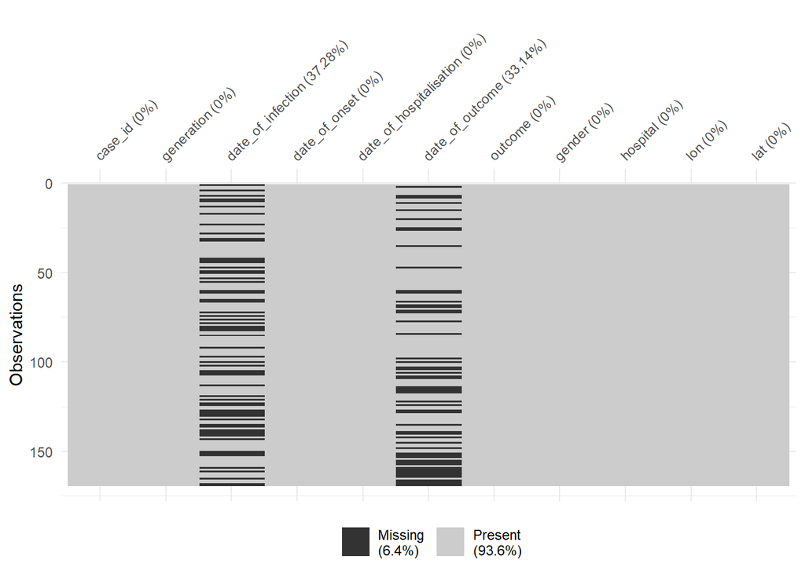

```r
casos_limpio %>% naniar::vis_miss()
```

> **P1.1: ¿Por qué cree que hay valores perdidos en dichas variables?**

## distribución en tiempo

- Tercero, crear un gráfico que permita ver la frecuencia de casos por unidad de tiempo.
- Para ello, crear un *histograma* usando el paquete [`ggplot2` (tutorial primer)](https://rstudio.cloud/learn/primers/3)
- **Importante:** Dentro de `ggplot2` usamos `+` para conectar a sus componentes y capas, de una forma simmilar al `%>%`
- **yapa:** ver video sobre [`ggplot2`](https://drive.google.com/drive/folders/1gynf5ooN-8ulVrysq5c6rPfZUcyscn04), diapositivas [aquí](https://bit.ly/r08ggplot2)

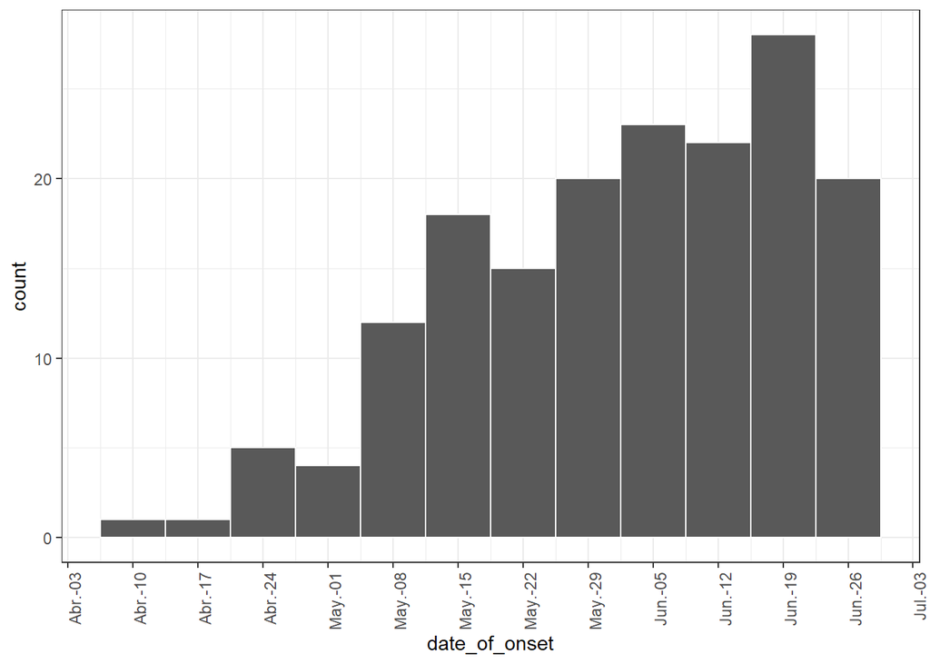

```r
casos_limpio %>%
  ggplot(aes(x = date_of_onset)) +
  geom_histogram(binwidth = 7, color="white") +
  scale_x_date(date_breaks = "7 day", date_labels = "%b-%d") +
  theme_bw() +
  theme(axis.text.x = element_text(angle = 90, hjust = 1))
```

> **P1.2: ¿Con qué otros análisis complementarías este gráfico?**

## distribución en espacio

- Cuarto, evaluaremos si hay una región o lugar con una mayor cantidad de casos recientes.
- Para ello, crear un diagrama de puntos. Pista: usar el [cheatsheet](https://github.com/rstudio/cheatsheets/blob/master/data-visualization-2.1.pdf) para descubrir más [geometrías](https://avallecam.github.io/workshop_ggplot2/presentation_ggplot2.html#28)!

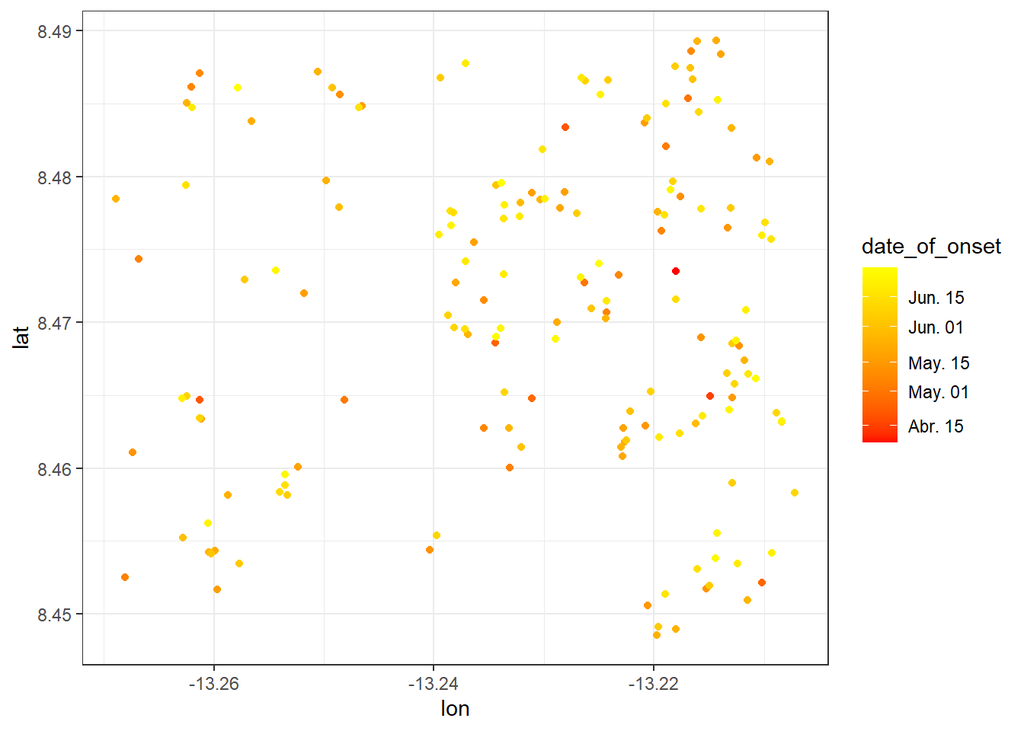

```r
casos_limpio %>%
  ggplot(aes(x = lon, y = lat, colour = date_of_onset)) +
  geom_point() +
  scale_color_gradient(low = "red", high = "yellow", trans = "date") +
  theme_bw()
```

> **P1.3: ¿Crees que hay una agregación espacial de casos? ¿Qué más harías para rechazar dicha hipótesis?**

## tabla descriptiva

- Quinto, describiremos las características de las persona en la base de datos
- Seleccionar columnas `outcome, gender, hospital` con la función `select()` usando el paquete [`dplyr` (tutorial primer)](https://rstudio.cloud/learn/primers/2)
- Crear una tabla con formato usando el paquete [`compareGroups`](https://cran.r-project.org/web/packages/compareGroups/vignettes/compareGroups_vignette.html) con la función `compareGroups()` y `createTable()`
- Usar `export2md()` para ver en un formato en HTML
- Transformar el orden de variables con la función `mutate()` y `fct_infreq()` usando el paquete [`dplyr` (tutorial primer)](https://rstudio.cloud/learn/primers/2.3)

```r
casos_limpio %>%
  select(outcome, gender, hospital) %>%
  mutate(hospital = fct_infreq(hospital),
         outcome = fct_infreq(outcome)) %>%
  compareGroups(~., data = .) %>%
  createTable() %>%
  export2md()
```

Summary descriptives table

|  | [ALL] | N |
| --- | --- | --- |
|  | N=169 |  |
| outcome: |  | 169 |
| NA | 65 (38.5%) |  |
| Death | 61 (36.1%) |  |
| Recover | 43 (25.4%) |  |
| gender: |  | 169 |
| f | 88 (52.1%) |  |
| m | 81 (47.9%) |  |
| hospital: |  | 169 |
| NA | 51 (30.2%) |  |
| Connaught Hospital | 47 (27.8%) |  |
| other | 25 (14.8%) |  |
| Military Hospital | 24 (14.2%) |  |
| Princess Christian Maternity Hospital (PCMH) | 12 (7.10%) |  |
| Rokupa Hospital | 9 (5.33%) |  |
| Mitylira Hospital | 1 (0.59%) |  |

> **P1.4: ¿Preguntas?**

# 02 - factores asociados

> Material original del evento [R aplicado a epidemiología](https://avallecam.github.io/epiapli2019/) y el paquete [`epitidy`](https://github.com/avallecam/epitidy)

## librerias a usar

```r
library(epitidy)
```

## importar base de datos

- Primero, inspeccionar documentación del estudio Whickham
- Importar base de datos posterior a una limpieza de datos

```r
# https://github.com/avallecam/epiapli2019/blob/master/02-clean_db.R
smoke_limpio <- "https://github.com/avallecam/epiapli2019/raw/master/data/smokeclean_20190906.rds"
smoke_clean <- rio::import(file = smoke_limpio)
smoke_clean
```

```
## # A tibble: 1,314 x 7
##    outcome smoker   age outcome_1 outcome_2 smoker_2 agegrp
##    <fct>   <fct>  <int>     <dbl> <fct>     <fct>    <fct>
##  1 Alive   Yes       23         0 Alive     Yes      18-44
##  2 Alive   Yes       18         0 Alive     Yes      18-44
##  3 Dead    Yes       71         1 Dead      Yes      65+
##  4 Alive   No        67         0 Alive     No       65+
##  5 Alive   No        64         0 Alive     No       45-64
##  6 Alive   Yes       38         0 Alive     Yes      18-44
##  7 Alive   Yes       45         0 Alive     Yes      45-64
##  8 Dead    No        76         1 Dead      No       65+
##  9 Alive   No        28         0 Alive     No       18-44
## 10 Alive   No        27         0 Alive     No       18-44
## # ... with 1,304 more rows
```

## tabla descriptiva

- Segundo, crear una tabla con formato usando el paquete [`compareGroups`](https://cran.r-project.org/web/packages/compareGroups/vignettes/compareGroups_vignette.html)
- según la variable dependiente `outcome`, describir la distribución de tres variables `smoker+agegrp+age`
- en la función `compareGroups()` especificar el argumento `byrow = T`
- en la función `createTable()` especificar los argumentos `show.all = T, sd.type = 2`

```r
tabla1 <- smoke_clean %>%
  compareGroups(outcome~smoker+agegrp+age, data = ., byrow = T) %>%
  createTable(show.all = T, sd.type = 2)

tabla1
```

```
##
## --------Summary descriptives table by 'outcome'---------
##
## _______________________________________________________
##              [ALL]       Alive       Dead     p.overall
##             N=1314       N=945       N=369
## ¯¯¯¯¯¯¯¯¯¯¯¯¯¯¯¯¯¯¯¯¯¯¯¯¯¯¯¯¯¯¯¯¯¯¯¯¯¯¯¯¯¯¯¯¯¯¯¯¯¯¯¯¯¯¯
## smoker:                                         0.003
##     No    732 (55.7%) 502 (68.6%) 230 (31.4%)
##     Yes   582 (44.3%) 443 (76.1%) 139 (23.9%)
## agegrp:                                        <0.001
##     18-44 624 (47.5%) 597 (95.7%) 27 (4.33%)
##     45-64 447 (34.0%) 314 (70.2%) 133 (29.8%)
##     65+   243 (18.5%) 34 (14.0%)  209 (86.0%)
## age        46.9±17.4   40.1±13.8   64.4±12.8   <0.001
## ¯¯¯¯¯¯¯¯¯¯¯¯¯¯¯¯¯¯¯¯¯¯¯¯¯¯¯¯¯¯¯¯¯¯¯¯¯¯¯¯¯¯¯¯¯¯¯¯¯¯¯¯¯¯¯
```

> **P2.1: ¿Qué tendencia logras identificar en las variables?**
- Tercero, exportar en formato XLSX con la función `export2xls()`

```r
tabla1 %>%
  export2xls("tabla/tabla02.xls")
```

## medidas de asociación

- Cuarto, estimar el riesgo de *fallecimiento* según el hábito de *fumar*.
- A un diseño de estudio epidemiológico de cohorte le corresponde estimar el Riesgo Relativo (RR)
- Para ello, construir modelos de regresión lineal con la función [`glm()`](https://lindeloev.github.io/tests-as-linear/) con familia de distribución *Poisson* función de enlace *log*
- Luego, limpiar salidas de modelos usando el paquete [`epitidy`](https://github.com/avallecam/epitidy) con la función `epi_tidymodel_rr()`

### modelo simple

```r
# smoke_clean %>% glimpse()

#simple
simple_model <- glm(outcome_1 ~ smoker,
                    data = smoke_clean,
                    family = poisson(link = "log"))
epi_tidymodel_rr(simple_model)
```

```
## # A tibble: 2 x 7
##   term        log.rr     se    rr conf.low conf.high p.value
##   <chr>        <dbl>  <dbl> <dbl>    <dbl>     <dbl>   <dbl>
## 1 (Intercept) -1.16  0.0659 0.314    0.275     0.357  0
## 2 smokerYes   -0.274 0.107  0.760    0.615     0.937  0.0107
```

### modelo múltiple

```r
#multiple: controlar por confusión
multiple_model <- glm(outcome_1 ~ smoker + age,
                      data = smoke_clean,
                      family = poisson(link = "log"))
epi_tidymodel_rr(multiple_model)
```

```
## # A tibble: 3 x 7
##   term         log.rr      se      rr conf.low conf.high p.value
##   <chr>         <dbl>   <dbl>   <dbl>    <dbl>     <dbl>   <dbl>
## 1 (Intercept) -4.96   0.261   0.00702  0.00416    0.0116   0
## 2 smokerYes    0.166  0.112   1.18     0.947      1.47     0.136
## 3 age          0.0644 0.00374 1.07     1.06       1.07     0
```

> **P2.2: ¿Cómo interpretas el cambio de RR entre muerte~fumar del modelo simple al modelo múltiple ajustado por edad?**
- exportar en formato XLSX usando el paquete `writexl` con la función `write_xlsx()`

```r
epi_tidymodel_rr(multiple_model) %>%
  writexl::write_xlsx("tabla/tabla03.xlsx")
```

### métodos alternativo

```r
# medidas de asociación ---------------------------------------------------

#epiR
library(epiR)
smoke_tabla1 <- with(smoke_clean,table(smoker_2,outcome_2)) %>% print()
epi.2by2(smoke_tabla1,method = "cohort.count")

#epiDisplay
library(epiDisplay)
smoke_tab2 <- with(smoke_clean,table(outcome,smoker)) %>% print()
cs(cctable = smoke_tab2)

# controlar por confusión -------------------------------------------------

#Mantel-Haenszel
smoke_tab3 <- with(smoke_clean,table(smoker_2,outcome_2,agegrp)) %>% print()
epi.2by2(smoke_tab3,method = "cohort.count")
mhor(mhtable=smoke_tab3,graph = F,design = "cohort")
```

> **P2.3: ¿Preguntas?**

# INTERMEDIO

> RETORNAMOS EN 5 MINUTOS

# 03 - curva epidémica

> Material ilustrativo disponible en la presentación [Análisis de múltiples epidemias y prevalencias con `R` y `purrr`](http://bit.ly/bbslisepi) y extraido del paquete [`incidenceflow`](https://github.com/avallecam/incidenceflow)

## librerias a usar

```r
library(outbreaks) #sample data
library(incidence) #core functions
library(incidenceflow)
```

## importar base de datos

- Primero, acceder a la base de datos `linelist` dentro de la lista `ebola_sim`

```r
ebola_sim$linelist %>% as_tibble()
```

```
## # A tibble: 5,888 x 11
##    case_id generation date_of_infection date_of_onset date_of_hospitalisation
##    <chr>        <int> <date>            <date>        <date>
##  1 d1fafd           0 NA                2014-04-07    2014-04-17
##  2 53371b           1 2014-04-09        2014-04-15    2014-04-20
##  3 f5c3d8           1 2014-04-18        2014-04-21    2014-04-25
##  4 6c286a           2 NA                2014-04-27    2014-04-27
##  5 0f58c4           2 2014-04-22        2014-04-26    2014-04-29
##  6 49731d           0 2014-03-19        2014-04-25    2014-05-02
##  7 f9149b           3 NA                2014-05-03    2014-05-04
##  8 881bd4           3 2014-04-26        2014-05-01    2014-05-05
##  9 e66fa4           2 NA                2014-04-21    2014-05-06
## 10 20b688           3 NA                2014-05-05    2014-05-06
## # ... with 5,878 more rows, and 6 more variables: date_of_outcome <date>,
## #   outcome <fct>, gender <fct>, hospital <fct>, lon <dbl>, lat <dbl>
```

- A partir de la base de datos `linelist`, extraer el vector `date_of_onset`

```r
dat <- ebola_sim$linelist$date_of_onset
enframe(dat,value = "date_of_onset") %>% select(date_of_onset)
```

```
## # A tibble: 5,888 x 1
##    date_of_onset
##    <date>
##  1 2014-04-07
##  2 2014-04-15
##  3 2014-04-21
##  4 2014-04-27
##  5 2014-04-26
##  6 2014-04-25
##  7 2014-05-03
##  8 2014-05-01
##  9 2014-04-21
## 10 2014-05-05
## # ... with 5,878 more rows
```

- Luego, configurar el vector aislado con la función `incidence()` y el argumento `interval=7`

```r
i.7 <- incidence(dat, interval=7)
i.7
```

```
## <incidence object>
## [5888 cases from days 2014-04-07 to 2015-04-27]
## [5888 cases from ISO weeks 2014-W15 to 2015-W18]
##
## $counts: matrix with 56 rows and 1 columns
## $n: 5888 cases in total
## $dates: 56 dates marking the left-side of bins
## $interval: 7 days
## $timespan: 386 days
## $cumulative: FALSE
```

- Generar un gráfico con la función `plot()`

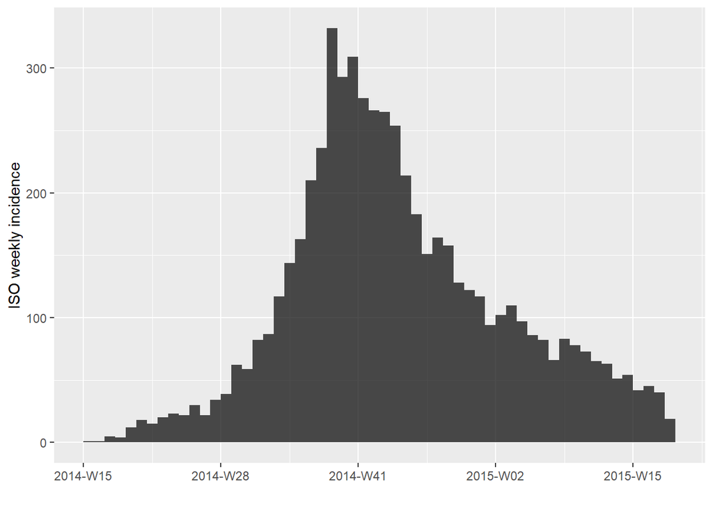

```r
plot(i.7)
```

## curva ascendente

```r
f1 <- fit(i.7[1:20])
f1
```

```
## <incidence_fit object>
##
## $model: regression of log-incidence over time
##
## $info: list containing the following items:
##   $r (daily growth rate):
## [1] 0.03175771
##
##   $r.conf (confidence interval):
##           2.5 %     97.5 %
## [1,] 0.02596229 0.03755314
##
##   $doubling (doubling time in days):
## [1] 21.8261
##
##   $doubling.conf (confidence interval):
##         2.5 %   97.5 %
## [1,] 18.45777 26.69823
##
##   $pred: data.frame of incidence predictions (20 rows, 5 columns)
```

## curva descendente

- Tercero, identificar punto de corte de la curva con la función `fit_optim_split()`

```r
f2 <- fit_optim_split(i.7)
f2
```

```
## $df
##         dates   mean.R2
## 1  2014-08-04 0.7650406
## 2  2014-08-11 0.8203351
## 3  2014-08-18 0.8598316
## 4  2014-08-25 0.8882682
## 5  2014-09-01 0.9120857
## 6  2014-09-08 0.9246023
## 7  2014-09-15 0.9338797
## 8  2014-09-22 0.9339813
## 9  2014-09-29 0.9333246
## 10 2014-10-06 0.9291131
## 11 2014-10-13 0.9232523
## 12 2014-10-20 0.9160439
## 13 2014-10-27 0.9071665
##
## $split
## [1] "2014-09-22"
##
## $fit
## <list of incidence_fit objects>
##
## attr(x, 'locations'): list of vectors with the locations of each incidence_fit object
##
## 'before'
## 'after'
##
## $model: regression of log-incidence over time
##
## $info: list containing the following items:
##   $r (daily growth rate):
##      before       after
##  0.02982209 -0.01016191
##
##   $r.conf (confidence interval):
##              2.5 %       97.5 %
## before  0.02608945  0.033554736
## after  -0.01102526 -0.009298561
##
##   $doubling (doubling time in days):
##   before
## 23.24274
##
##   $doubling.conf (confidence interval):
##           2.5 %  97.5 %
## before 20.65721 26.5681
##
##   $halving (halving time in days):
##    after
## 68.21031
##
##   $halving.conf (confidence interval):
##          2.5 %   97.5 %
## after 62.86899 74.54349
##
##   $pred: data.frame of incidence predictions (57 rows, 6 columns)
##
## $plot
```

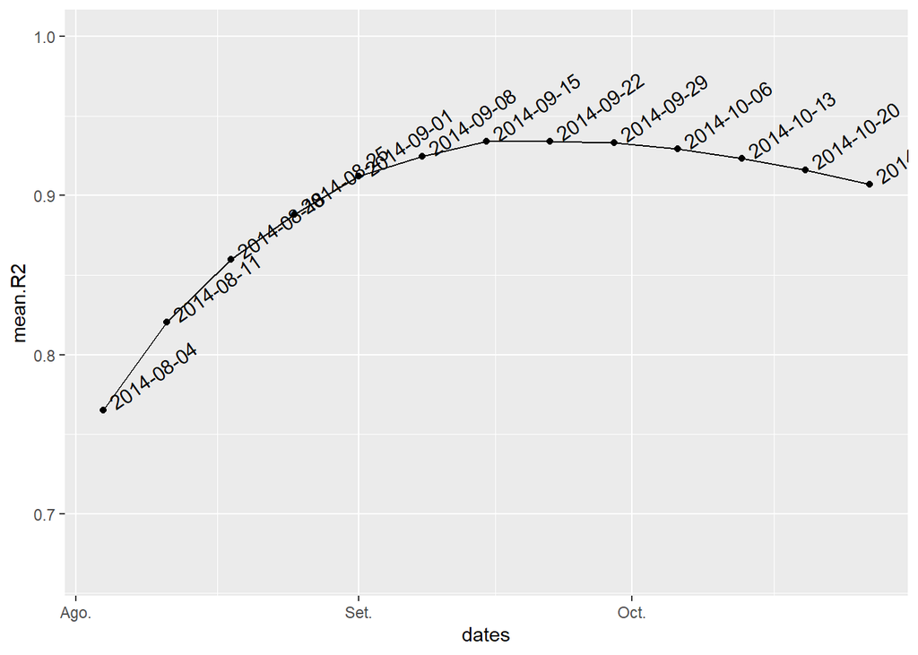

## generar tablas resumen

- Cuarta, transformar salidas a formato base de datos usando el paquete [`incidenceflow`](https://github.com/avallecam/incidenceflow)

### curva ascendente

- Con la función `tidy_incidence()` generamos una tabla solo con la *tasa de crecimiento* y *tiempo de duplicación*

```r
f1 %>% tidy_incidence()
```

```
## # A tibble: 2 x 5
##   mark  parameter estimate conf_lower conf_upper
##   <chr> <chr>        <dbl>      <dbl>      <dbl>
## 1 1     r           0.0318     0.0260     0.0376
## 2 1     doubling   21.8       18.5       26.7
```

- Con la función `glance_incidence()` generamos una tabla solo con las medidas de *bondad de ajuste* del modelo lineal

```r
f1 %>% glance_incidence()
```

```
## # A tibble: 1 x 12
##   r.squared adj.r.squared sigma statistic  p.value    df logLik   AIC   BIC
##       <dbl>         <dbl> <dbl>     <dbl>    <dbl> <dbl>  <dbl> <dbl> <dbl>
## 1     0.880         0.874 0.498      133. 9.81e-10     1  -13.4  32.8  35.7
## # ... with 3 more variables: deviance <dbl>, df.residual <int>, nobs <int>
```

### curva descendente

```r
f2 %>% pluck("fit") %>% tidy_incidence()
```

```
## # A tibble: 4 x 5
##   mark   parameter estimate conf_lower conf_upper
##   <chr>  <chr>        <dbl>      <dbl>      <dbl>
## 1 before r           0.0298     0.0261    0.0336
## 2 after  r          -0.0102    -0.0110   -0.00930
## 3 before doubling   23.2       20.7      26.6
## 4 after  halving    68.2       62.9      74.5
```

```r
f2 %>% pluck("fit") %>% glance_incidence()
```

```
## # A tibble: 2 x 13
##   names  r.squared adj.r.squared sigma statistic  p.value    df logLik   AIC
##   <chr>      <dbl>         <dbl> <dbl>     <dbl>    <dbl> <dbl>  <dbl> <dbl>
## 1 before     0.922         0.919 0.455      273. 2.95e-14     1  -14.8  35.5
## 2 after      0.951         0.949 0.155      578. 3.72e-21     1   15.4 -24.8
## # ... with 4 more variables: BIC <dbl>, deviance <dbl>, df.residual <int>,
## #   nobs <int>
```

> **P3.1: ¿La tasa de crecimiento estimada antes y despúes del punto de corte es concordante con lo observado en el gráfico?**

> **P3.2: ¿Preguntas?**

# 04 - canal endémico

> Material extraído del paquete [`epichannel`](https://github.com/avallecam/epichannel)

## librerias a usar

```r
library(epichannel)
```

## importar base de datos

- Primero, *leer* datos de vigilancia usando el paquete [`readr`](https://readr.tidyverse.org/) con la función `read_csv()`
- Transformar algunas variables al formato adecuado

### datos de enfermedad

```r
denv <-
  readr::read_csv("https://predict.cdc.gov/api/v1/attachments/dengue%20forecasting%20project/iquitos_training_data.csv") %>%
  mutate(year = lubridate::year(week_start_date),
         epiweek = lubridate::epiweek(week_start_date)) %>%
  mutate(adm="iquitos") %>%
  # cases per season - replace wiht a dummy year
  mutate(year = str_replace(season,"(.+)/(.+)","\\1") %>% as.double())

denv %>% glimpse()
```

```
## Rows: 468
## Columns: 12
## $ season               <chr> "2000/2001", "2000/2001", "2000/2001", "2000/2001~
## $ season_week          <dbl> 1, 2, 3, 4, 5, 6, 7, 8, 9, 10, 11, 12, 13, 14, 15~
## $ week_start_date      <date> 2000-07-01, 2000-07-08, 2000-07-15, 2000-07-22, ~
## $ denv1_cases          <dbl> 0, 0, 0, 0, 0, 0, 0, 0, 0, 0, 0, 0, 0, 0, 0, 0, 0~
## $ denv2_cases          <dbl> 0, 0, 0, 0, 0, 0, 0, 0, 0, 0, 0, 0, 0, 0, 0, 0, 0~
## $ denv3_cases          <dbl> 0, 0, 0, 0, 0, 0, 0, 0, 0, 0, 0, 0, 0, 0, 0, 0, 0~
## $ denv4_cases          <dbl> 0, 0, 0, 0, 0, 0, 0, 0, 0, 0, 0, 0, 0, 0, 0, 0, 0~
## $ other_positive_cases <dbl> 0, 0, 0, 0, 0, 0, 0, 0, 0, 0, 1, 0, 0, 0, 0, 1, 1~
## $ total_cases          <dbl> 0, 0, 0, 0, 0, 0, 0, 0, 0, 0, 1, 0, 0, 0, 0, 1, 1~
## $ year                 <dbl> 2000, 2000, 2000, 2000, 2000, 2000, 2000, 2000, 2~
## $ epiweek              <dbl> 26, 27, 28, 29, 30, 31, 32, 33, 34, 35, 36, 37, 3~
## $ adm                  <chr> "iquitos", "iquitos", "iquitos", "iquitos", "iqui~
```

### datos de población

```r
popdb <-
  readr::read_csv("https://predict.cdc.gov/api/v1/attachments/dengue%20forecasting%20project/iquitos_population_data.csv") %>%
  janitor::clean_names() %>%
  mutate(adm="iquitos")

popdb %>% glimpse()
```

```
## Rows: 15
## Columns: 3
## $ year                 <dbl> 2000, 2001, 2002, 2003, 2004, 2005, 2006, 2007, 2~
## $ estimated_population <dbl> 386666, 393355, 399770, 405988, 412095, 418168, 4~
## $ adm                  <chr> "iquitos", "iquitos", "iquitos", "iquitos", "iqui~
```

## adaptar bases de datos

- Segundo, *adaptar* ambas bases de datos con la función `epi_adapt_timeserie()`

```r
epi_adapted <-
  epi_adapt_timeserie(db_disease = denv,
                      db_population = popdb,
                      var_admx = adm,
                      var_year = year, # must be a common variable name between datasets
                      var_week = season_week,
                      # var_year = year,
                      # var_week = epiweek,
                      var_event_count = total_cases,
                      var_population = estimated_population)
# epi_adapted
```

## filtrar por años

- Tercero, *filtrar* por años para discriminar entre datos de años históricos (diferentes al último año) y año corriente (iguales al último año) con la función `filter()`.
- Filtrar filas usando el paquete [`dplyr` (tutorial primer)](https://rstudio.cloud/learn/primers/2)

```r
disease_now <- epi_adapted %>%
  filter(var_year==max(var_year))

disease_pre <- epi_adapted %>%
  filter(var_year!=max(var_year))
```

## crear canal endémico

- Cuarto, *crear* el **canal endémico** con la función `epi_create_channel()`
  - Aquí puedes elegir entre tres métodos disponibles [(Bortman, 1999)](https://doi.org/10.1590/S1020-49891999000100001):
    - `"gmean_1sd"` es media geométrica con 1 desviación estándar (por defecto).
    - `"gmean_2sd"` es media geométrica con 2 desviaciones estándar.
    - `"gmean_ci"` es media geométrica con intervalos de confianza al 95%.

```r
disease_channel <-
  epi_create_channel(time_serie = disease_pre,
                     disease_name = "denv",
                     method = "gmean_1sd")
disease_channel
```

```
## # A tibble: 52 x 6
##    var_admx var_week median  low_95 upp_95 key
##    <fct>       <dbl>  <dbl>   <dbl>  <dbl> <chr>
##  1 iquitos         1   2.80  0.267    6.80 denv
##  2 iquitos         2   2.64  0.484    5.82 denv
##  3 iquitos         3   2.78  0.259    6.75 denv
##  4 iquitos         4   2.86  0.424    6.62 denv
##  5 iquitos         5   2.72  0.454    6.12 denv
##  6 iquitos         6   2.25  0.127    5.44 denv
##  7 iquitos         7   2.22  0.0474   5.52 denv
##  8 iquitos         8   2.34  0.167    5.61 denv
##  9 iquitos         9   1.82 -0.420    5.44 denv
## 10 iquitos        10   2.66 -0.513    8.65 denv
## # ... with 42 more rows
```

## unir y graficar canal

- Finalmente, *unir* bases con `epi_join_channel()` y
- *Graficar* usando ggplot con `epi_plot_channel()`

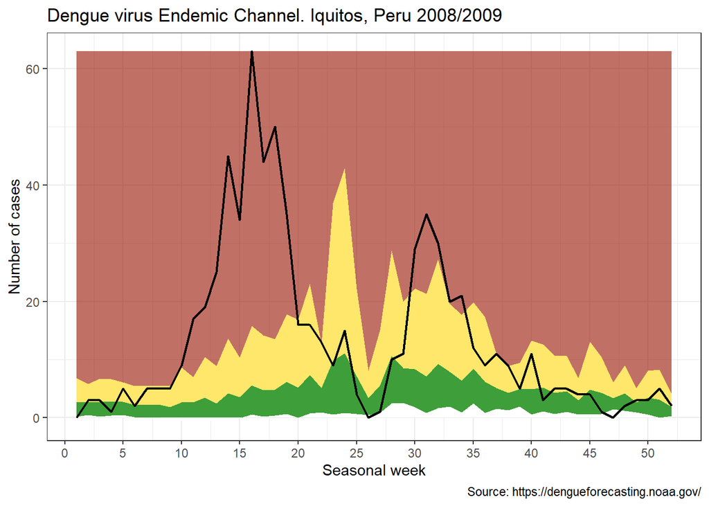

```r
epi_join_channel(disease_channel = disease_channel,
                 disease_now = disease_now) %>%
  # ggplot
  epi_plot_channel() +
  labs(title = "Dengue virus Endemic Channel. Iquitos, Peru 2008/2009",
       caption = "Source: https://dengueforecasting.noaa.gov/",
       # x = "epiweeks",
       x = "Seasonal week",
       y = "Number of cases") +
  theme_bw()
```

> **P4.1: ¿Por qué crees que hay una disminución repentina de casos y de zonas del canal entre las semanas estacionales 20 y 30 (diciembre - enero)?**

> **P4.2: ¿Preguntas?**

# 05 - difusión

Aquí lista de recursos útiles para construir y publicar tableros de comando o *dashboards*

- Visualizando datos de Salud Pública y Epidemiología de campo para el Diplomado 2021 en diapositivas
- LatinR 2020: Aplicaciones web interactivas con Shiny - [video](https://www.youtube.com/watch?v=sryZCC9z2po) y repositorio de [materiales](https://github.com/flor14/latinr_shiny_2020)
- Rstudio Webinar sobre el paquete [`flexdashboards`](https://www.rstudio.com/resources/webinars/introducing-flexdashboards/)

# 06 - cierre

## ¡Gracias por su atención!

### Andree Valle Campos **`@avallecam`** [click aquí](https://twitter.com/avallecam) **avallecam@gmail.com**

#### código completo

```r
# instalar paquetes si se requiere ----------------------------------------

if(!require("remotes")) install.packages("remotes")
if(!require("tidyverse")) install.packages("tidyverse")
if(!require("lubridate")) install.packages("lubridate")
if(!require("compareGroups")) install.packages("compareGroups")
if(!require("rio")) install.packages("rio")
if(!require("naniar")) install.packages("naniar")
if(!require("incidence")) install.packages("incidence")
if(!require("epiR")) install.packages("epiR")
if(!require("epiDisplay")) install.packages("epiDisplay")
if(!require("epitidy")) remotes::install_github("avallecam/epitidy")
if(!require("incidenceflow")) remotes::install_github("avallecam/incidenceflow")
if(!require("epichannel")) remotes::install_github("avallecam/epichannel")


# # 01 - tiempo espacio persona ------------------------------------
# ## _librerias a usar ---------------------------------

library(tidyverse)
library(lubridate)
library(compareGroups)

# ## _importar base de datos ---------------------------------

ruta_limpio <- "https://github.com/avallecam/epiapli2019/raw/master/data/casoslimpio_20190916.rds"
casos_limpio <- rio::import(file = ruta_limpio)
casos_limpio

casos_limpio %>% naniar::miss_var_summary()
casos_limpio %>% naniar::vis_miss()

# ## _distribución en tiempo ---------------------------------

casos_limpio %>%
  ggplot(aes(x = date_of_onset)) +
  geom_histogram(binwidth = 7, color="white") +
  scale_x_date(date_breaks = "7 day", date_labels = "%b-%d") +
  theme_bw() +
  theme(axis.text.x = element_text(angle = 90, hjust = 1))

# ## _distribución en espacio ---------------------------------

casos_limpio %>%
  ggplot(aes(x = lon, y = lat, colour = date_of_onset)) +
  geom_point() +
  scale_color_gradient(low = "red", high = "yellow", trans = "date") +
  theme_bw()

# ## _tabla descriptiva ---------------------------------

casos_limpio %>%
  select(outcome, gender, hospital) %>%
  mutate(hospital = fct_infreq(hospital),
         outcome = fct_infreq(outcome)) %>%
  compareGroups(~., data = .) %>%
  createTable() %>%
  export2md()


# # 02 - factores asociados ------------------------------------
# ## _librerias a usar ---------------------------------

library(epitidy)

# ## _importar base de datos ---------------------------------

## # dentro de R
## if(!require("mosaicData")) install.packages("mosaicData")
## ?mosaicData::Whickham

smoke_limpio <- "https://github.com/avallecam/epiapli2019/raw/master/data/smokeclean_20190906.rds"
smoke_clean <- rio::import(file = smoke_limpio)
smoke_clean

# ## _tabla descriptiva ---------------------------------

tabla1 <- smoke_clean %>%
  compareGroups(outcome~smoker+agegrp+age, data = ., byrow = T) %>%
  createTable(show.all = T, sd.type = 2)

tabla1

## tabla1 %>%
##   export2xls("tabla/tabla02.xls")

# ## _medidas de asociación ---------------------------------

# ###__ modelo simple ---------------------------------

# smoke_clean %>% glimpse()

#simple
simple_model <- glm(outcome_1 ~ smoker,
                    data = smoke_clean,
                    family = poisson(link = "log"))
epi_tidymodel_rr(simple_model)



# ###__ modelo múltiple ---------------------------------

#multiple: controlar por confusión
multiple_model <- glm(outcome_1 ~ smoker + age,
                      data = smoke_clean,
                      family = poisson(link = "log"))
epi_tidymodel_rr(multiple_model)

## epi_tidymodel_rr(multiple_model) %>%
##   writexl::write_xlsx("tabla/tabla03.xlsx")

## # medidas de asociación ---------------------------------------------------
##
## #epiR
## library(epiR)
## smoke_tabla1 <- with(smoke_clean,table(smoker_2,outcome_2)) %>% print()
## epi.2by2(smoke_tabla1,method = "cohort.count")
##
## #epiDisplay
## library(epiDisplay)
## smoke_tab2 <- with(smoke_clean,table(outcome,smoker)) %>% print()
## cs(cctable = smoke_tab2)
##
## # controlar por confusión -------------------------------------------------
##
## #Mantel-Haenszel
## smoke_tab3 <- with(smoke_clean,table(smoker_2,outcome_2,agegrp)) %>% print()
## epi.2by2(smoke_tab3,method = "cohort.count")
## mhor(mhtable=smoke_tab3,graph = F,design = "cohort")


# # 03 - curva epidémica ------------------------------------
# ## _librerias a usar ---------------------------------

library(outbreaks) #sample data
library(incidence) #core functions
library(incidenceflow)

# ## _importar base de datos ---------------------------------

ebola_sim$linelist %>% as_tibble()

dat <- ebola_sim$linelist$date_of_onset
enframe(dat,value = "date_of_onset") %>% select(date_of_onset)

i.7 <- incidence(dat, interval=7)
i.7

plot(i.7)

# ## _curva ascendente ---------------------------------

f1 <- fit(i.7[1:20])
f1

# ## _curva descendente ---------------------------------

f2 <- fit_optim_split(i.7)
f2

# ## _generar tablas resumen ---------------------------------
# ###__ curva ascendente ---------------------------------

f1 %>% tidy_incidence()

f1 %>% glance_incidence()

# ###__ curva descendente ---------------------------------

f2 %>% pluck("fit") %>% tidy_incidence()

f2 %>% pluck("fit") %>% glance_incidence()

# # 04 - canal endémico ------------------------------------
# ## _librerias a usar ---------------------------------

library(epichannel)

# ## _importar base de datos ---------------------------------
# ###__ datos de enfermedad ---------------------------------

denv <-
  readr::read_csv("https://predict.cdc.gov/api/v1/attachments/dengue%20forecasting%20project/iquitos_training_data.csv") %>%
  mutate(year = lubridate::year(week_start_date),
         epiweek = lubridate::epiweek(week_start_date)) %>%
  mutate(adm="iquitos") %>%
  # cases per season - replace wiht a dummy year
  mutate(year = str_replace(season,"(.+)/(.+)","\\1") %>% as.double())

denv %>% glimpse()

# ###__ datos de población ---------------------------------

popdb <-
  readr::read_csv("https://predict.cdc.gov/api/v1/attachments/dengue%20forecasting%20project/iquitos_population_data.csv") %>%
  janitor::clean_names() %>%
  mutate(adm="iquitos")

popdb %>% glimpse()

## # denv %>% count(year,season,lag_year)
## # denv %>%
## #   ggplot(aes(x = week_start_date,y = total_cases)) +
## #   geom_col()
## # popdb %>% count(year)
## # denv %>% count(year)
## # denv %>% left_join(popdb)

# ## _adaptar bases de datos ---------------------------------

epi_adapted <-
  epi_adapt_timeserie(db_disease = denv,
                      db_population = popdb,
                      var_admx = adm,
                      var_year = year, # must be a common variable name between datasets
                      var_week = season_week,
                      # var_year = year,
                      # var_week = epiweek,
                      var_event_count = total_cases,
                      var_population = estimated_population)
epi_adapted

# ## _filtrar por años ---------------------------------

disease_now <- epi_adapted %>%
  filter(var_year==max(var_year))

disease_pre <- epi_adapted %>%
  filter(var_year!=max(var_year))

# ## _crear canal endémico ---------------------------------

disease_channel <-
  epi_create_channel(time_serie = disease_pre,
                     disease_name = "denv",
                     method = "gmean_1sd")
disease_channel

# ## _unir y graficar canal ---------------------------------

epi_join_channel(disease_channel = disease_channel,
                 disease_now = disease_now) %>%
  # ggplot
  epi_plot_channel() +
  labs(title = "Dengue virus Endemic Channel. Iquitos, Peru 2008/2009",
       caption = "Source: https://dengueforecasting.noaa.gov/",
       # x = "epiweeks",
       x = "Seasonal week",
       y = "Number of cases") +
  theme_bw()
```